# BIRAX study - injection demand model validation

David M Wright - d.wright@qub.ac.uk

Document compiled: 2023-07-05

R version 4.3.0 (2023-04-21 ucrt)

# 1 Introduction

This analysis is of Electronic Medical Records (EMR) from the Tel Aviv Sourasky Medical Centre (TASMC) extracted over the period 2014-04-27 to 2022-07-31. The aim of the study is to investigate the potential for machine learning to identify factors and biomarkers associated with long-term AMD treatment response.

This analysis investigates the extent to which the number of anti-VEGF injections received by each eye and visual acuity following treatment can be predicted based on measurements of retinal fluid produced by the Notal Ophthalmic Analyzer (NOA) at baseline and at six months. Models for these outcomes were trained using data from the Belfast Health and Social Care Trust. This is an external validation using the TASMC data.

The following outcomes were investigated:

1. The number of injections received by an eye in each of the first three years of treatment.
2. Visual acuity at the end of each year of treatment.

Cohort construction is described in ’TASMC-cohort-construction.html` (1024 eyes from 821 patients).

- Excluded 411 eyes without a fluid measurement at 6 months (+-2 months, Figure 1.1).

A total of 613 eyes from 526 patients remained after these exclusions.

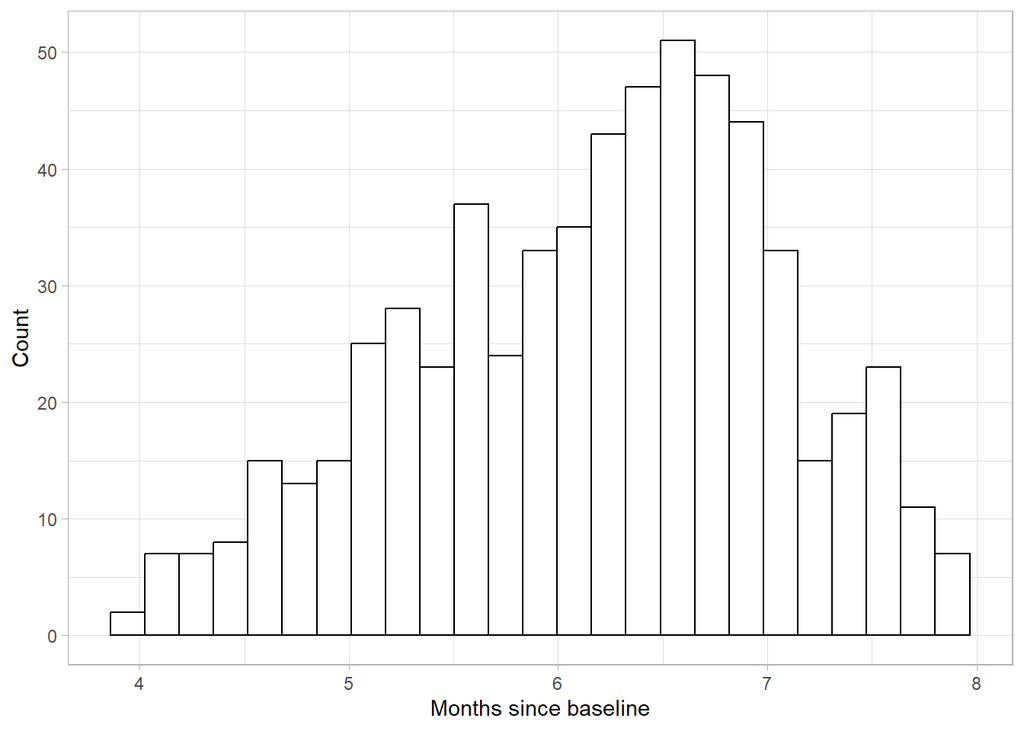

Figure 1.1: Distribution of actual times since baseline for the ‘Six month’ fluid measurement.

## 1.1 Patient characteristics

Table 1.1: Baseline characteristics of eyes with AMD. Frequency and percentage reported for categorical variables.

| Variable | Level | Value | n |
| --- | --- | --- | --- |
| Age | Mean (Range) | 80.6 (50.1, 101) | NA |
| Gender | F | NA | 335 (54.6%) |
| Gender | M | NA | 278 (45.4%) |
| Eyes |  | NA | 613 (100%) |

Table 1.2: Number of injections and examinations in first three years of treatment.

| Variable | Level | Value | n |
| --- | --- | --- | --- |
| Injections | Median (IQR) | 17 (10, 23) | NA |
| Total injections |  | 10102 (100%) | NA |
| Total VA exams |  | NA | 6666 (100%) |
| VA exams | Median (Range) | 11 (1, 38) | NA |
| VA years observed | Median (Range) | 2.64 (0.345, 3) | NA |
| Total OCT fluid measurements |  | NA | 5569 (100%) |
| OCT fluid measurements | Median (Range) | 9 (2, 28) | NA |
| OCT fluid years observed | Median (Range) | 2.28 (0.337, 2.99) | NA |

## 1.2 Visual acuity

Table 1.3: Distribution of visual acuity outcomes at baseline.

| Description | Level | Value | n |
| --- | --- | --- | --- |
| Visual acuity (LogMAR) | Median (Range) | 0.48 (0, 2.3) | NA |
| Visual acuity category (Snellen) | Good (VA>6/12) | NA | 223 (36.9%) |
| Visual acuity category (Snellen) | Moderate (6/24 < VA <= 6/12) | NA | 119 (19.7%) |
| Visual acuity category (Snellen) | Partially sighted (6/60 < VA <= 6/24) | NA | 124 (20.5%) |
| Visual acuity category (Snellen) | Blind (VA <= 6/60) | NA | 139 (23%) |
| Eyes | n | NA | 605 (100%) |

Table 1.4: Distribution of visual acuity outcomes at baseline by fluid presence.

| Description | Level | No fluid | SRF only | IRF only | SRF and IRF |
| --- | --- | --- | --- | --- | --- |
| Visual acuity (LogMAR) | Median (Range) | 0.26 (0, 1.52) | 0.26 (0, 2.3) | 0.44 (0, 1.85) | 0.66 (0, 2.3) |
| Visual acuity category (Snellen) | Good (VA>6/12) | 13 (52%) | 86 (56.2%) | 44 (36.1%) | 80 (26.2%) |
| Visual acuity category (Snellen) | Moderate (6/24 < VA <= 6/12) | 4 (16%) | 31 (20.3%) | 30 (24.6%) | 54 (17.7%) |
| Visual acuity category (Snellen) | Partially sighted (6/60 < VA <= 6/24) | 5 (20%) | 22 (14.4%) | 24 (19.7%) | 73 (23.9%) |
| Visual acuity category (Snellen) | Blind (VA <= 6/60) | 3 (12%) | 14 (9.15%) | 24 (19.7%) | 98 (32.1%) |
| Eyes | n | 25 (100%) | 153 (100%) | 122 (100%) | 305 (100%) |

# 2 Machine learning pipeline

An ensemble machine learning pipeline was used to find the best prediction for each eye, using a diverse set of learners to capture interactions and non-linear relationships among variables in the absence of a-priori information on the correct functional form. The fluid measurements are listed in Table 2.1 and prior to model fitting, each variable was standardised and missing measurements were imputed with zero. Baseline and six month measurements for each variable were used

Table 2.1: Retinal fluid measurements included in models predicting injection demand.

| Variable | Parameter | Unit/Type | Category | Description | abbr_metric |
| --- | --- | --- | --- | --- | --- |
| Superior3_vol[nl] | Inner Superior Sub Field Volume of the retina | [nl] | ETDRS Grid Parameters | Retinal volume within the superior quadrant of circle with a 3 mm diameter | Volume of the retina |
| Nasal3_vol[nl] | Inner Nasal Sub Field Volume of the retina (NS) | [nl] | ETDRS Grid Parameters | Retinal volume within the nasal quadrant of circle with a 3 mm diameter | Volume of the retina |
| Inferior3_vol[nl] | Inner Inferior Sub Field Volume of the retina (IS) | [nl] | ETDRS Grid Parameters | Retinal volume within the inferior quadrant of circle with a 3 mm diameter | Volume of the retina |
| Tempo3_vol[nl] | Inner Temporal Sub Field Volume of the retina (TS) | [nl] | ETDRS Grid Parameters | Retinal volume within the temporal quadrant of circle with a 3 mm diameter | Volume of the retina |
| Superior6_vol[nl] | Inner Superior Sub Field Volume of the retina | [nl] | ETDRS Grid Parameters | Retinal volume within the superior quadrant of circle with a 6 mm diameter | Volume of the retina |
| Nasal6_vol[nl] | Inner Nasal Sub Field Volume of the retina (NS) | [nl] | ETDRS Grid Parameters | Retinal volume within the nasal quadrant of circle with a 6mm diameter | Volume of the retina |
| Inferior6_vol[nl] | Inner Inferior Sub Field Volume of the retina (IS) | [nl] | ETDRS Grid Parameters | Retinal volume within the inferior quadrant of circle with a 6 mm diameter | Volume of the retina |
| Tempo6_vol[nl] | Inner Temporal Sub Field Volume of the retina (TS) | [nl] | ETDRS Grid Parameters | Retinal volume within the temporal quadrant of circle with a 6 mm diameter | Volume of the retina |
| Superior3_vol(RPE)[nl] | RPE irregularities superior3 volume (Inner Superior) | [nl] | ETDRS Grid Parameters | RPE irregularities volume within the ETDRS fields (see macular map below) | RPE irregularities volume |
| Nasal3_vol(RPE)[nl] | RPE irregularities Nasal3 volume (Inner Nasal) | [nl] | ETDRS Grid Parameters | RPE irregularities volume within the ETDRS fields (see macular map below) | RPE irregularities volume |
| Inferior3_vol(RPE)[nl] | RPE irregularities inferior3 volume (Inner inferior) | [nl] | ETDRS Grid Parameters | RPE irregularities volume within the ETDRS fields (see macular map below) | RPE irregularities volume |
| Tempo3_vol(RPE)[nl] | RPE irregularities Tempo3 volume (Inner Temporal) | [nl] | ETDRS Grid Parameters | RPE irregularities volume within the ETDRS fields (see macular map below) | RPE irregularities volume |
| Superior6_vol(RPE)[nl] | RPE irregularities superior6 volume (Outer Superior) | [nl] | ETDRS Grid Parameters | RPE irregularities volume within the ETDRS fields (see macular map below) | RPE irregularities volume |
| Nasal6_vol(RPE)[nl] | RPE irregularities Nasal6 volume (Outer Nasal) | [nl] | ETDRS Grid Parameters | RPE irregularities volume within the ETDRS fields (see macular map below) | RPE irregularities volume |
| Inferior6_vol(RPE)[nl] | RPE irregularities inferior6 volume (Outer Inferior) | [nl] | ETDRS Grid Parameters | RPE irregularities volume within the ETDRS fields (see macular map below) | RPE irregularities volume |
| Tempo6_vol(RPE)[nl] | RPE irregularities Tempo6 volume (Outer Temporal) | [nl] | ETDRS Grid Parameters | RPE irregularities volume within the ETDRS fields (see macular map below) | RPE irregularities volume |
| Volume_of_RPE_irregularities[nl] | Volume of RPE irregularities | [nl] | Retinal parameters | Including drusen and PED, multiplied by the distance between B-scans within the analyzed en-face area | Volume of RPE irregularities |
| PED volume[nl] | Volume of retinal pigment epithelial detachment (PED) | [nl] | Retinal parameters | Volume of retinal pigment epithelial detachment within the analyzed en-face area | Volume of retinal pigment epithelial detachment PED |
| SRFVolumeNl | SRF Volume | [nl] | Fluid Parameters | Sum of the area of SRF regions multiplied by the distance between B-scans within the analyzed en-face area | SRF Volume |
| IRFVolumeNl | IRF Volume | [nl] | Fluid Parameters | Sum of the area of IRF regions multiplied by the distance between B-scans within the analyzed en-face area | IRF Volume |
| ERMVolumeNl | Vitrous-Macula Interface (VMI) abnormalities | [nl] | Retinal parameters | Volume of hyporeflective regions that interface with the ILM which are not classified as IRF | Vitrous-Macula Interface VMI abnormalities |
| Retinal_volumeNl | Retinal volume | [nl] | Retinal parameters | The volume of the retina within the analyzed en-face area based on ILM to RPE delineation | Retinal volume |
| Superior3_vol(SRF)[nl] | SRF Inner Superior Sub Field Volume | [nl] | ETDRS Grid Parameters | SRF volume within the superior quadrant of circle with a 3 mm diameter | SRF Volume |
| Nasal3_vol(SRF)[nl] | SRF Inner Nasal Sub Field Volume | [nl] | ETDRS Grid Parameters | SRF volume within the nasal quadrant of circle with a 3 mm diameter | SRF Volume |
| Inferior3_vol(SRF)[nl] | SRF Inner Inferior Sub Field Volume | [nl] | ETDRS Grid Parameters | SRF volume within the inferior quadrant of circle with a 3 mm diameter | SRF Volume |
| Tempo3_vol(SRF)[nl] | SRF Inner Temporal Sub Field Volume | [nl] | ETDRS Grid Parameters | SRF volume within the temporal quadrant of circle with a 3 mm diameter | SRF Volume |
| Superior6_vol(SRF)[nl] | SRF Inner Superior Sub Field Volume | [nl] | ETDRS Grid Parameters | SRF volume within the superior quadrant of circle with a 6 mm diameter | SRF Volume |
| Nasal6_vol(SRF)[nl] | SRF Inner Nasal Sub Field Volume | [nl] | ETDRS Grid Parameters | SRF volume within the nasal quadrant of circle with a 6mm diameter | SRF Volume |
| Inferior6_vol(SRF)[nl] | SRF Inner Inferior Sub Field Volume | [nl] | ETDRS Grid Parameters | SRF volume within the inferior quadrant of circle with a 6 mm diameter | SRF Volume |
| Tempo6_vol(SRF)[nl] | SRF Inner Temporal Sub Field Volume | [nl] | ETDRS Grid Parameters | SRF volume within the temporal quadrant of circle with a 6 mm diameter | SRF Volume |
| Superior3_vol(IRF)[nl] | IRF Inner Superior Sub Field Volume | [nl] | ETDRS Grid Parameters | IRF volume within the superior quadrant of circle with a 3 mm diameter | IRF Volume |
| Nasal3_vol(IRF)[nl] | IRF Inner Nasal Sub Field Volume | [nl] | ETDRS Grid Parameters | IRF volume within the nasal quadrant of circle with a 3 mm diameter | IRF Volume |
| Inferior3_vol(IRF)[nl] | IRF Inner Inferior Sub Field Volume | [nl] | ETDRS Grid Parameters | IRF volume within the inferior quadrant of circle with a 3 mm diameter | IRF Volume |
| Tempo3_vol(IRF)[nl] | IRF Inner Temporal Sub Field Volume | [nl] | ETDRS Grid Parameters | IRF volume within the temporal quadrant of circle with a 3 mm diameter | IRF Volume |
| Superior6_vol(IRF)[nl] | IRF Inner Superior Sub Field Volume | [nl] | ETDRS Grid Parameters | IRF volume within the superior quadrant of circle with a 6 mm diameter | IRF Volume |
| Nasal6_vol(IRF)[nl] | IRF Inner Nasal Sub Field Volume | [nl] | ETDRS Grid Parameters | IRF volume within the nasal quadrant of circle with a 6mm diameter | IRF Volume |
| Inferior6_vol(IRF)[nl] | IRF Inner Inferior Sub Field Volume | [nl] | ETDRS Grid Parameters | IRF volume within the inferior quadrant of circle with a 6 mm diameter | IRF Volume |
| Tempo6_vol(IRF)[nl] | IRF Inner Temporal Sub Field Volume | [nl] | ETDRS Grid Parameters | IRF volume within the temporal quadrant of circle with a 6 mm diameter | IRF Volume |

# 3 Injections by treatment year

Table 3.1: Prediction characteristics of fitted models by year.

| outcome | method | term | estimate | p |
| --- | --- | --- | --- | --- |
| in_yr_1 | Pearson’s product-moment correlation | NA | 0.26 | < 0.001 |
| in_yr_1 | Linear regression (calibration) | (Intercept) | 3.27 | < 0.001 |
| in_yr_1 | Linear regression (calibration) | pred_Y | 0.80 | < 0.001 |
| in_yr_1 | Deviation | mean | 2.15 | NA |
| in_yr_1 | Absolute deviation | mean | 2.75 | NA |
| in_yr_2 | Pearson’s product-moment correlation | NA | 0.25 | < 0.001 |
| in_yr_2 | Linear regression (calibration) | (Intercept) | 2.28 | < 0.001 |
| in_yr_2 | Linear regression (calibration) | pred_Y | 0.93 | < 0.001 |
| in_yr_2 | Deviation | mean | 2.08 | NA |
| in_yr_2 | Absolute deviation | mean | 3.39 | NA |
| in_yr_3 | Pearson’s product-moment correlation | NA | 0.22 | < 0.001 |
| in_yr_3 | Linear regression (calibration) | (Intercept) | 1.04 | 0.023811 |
| in_yr_3 | Linear regression (calibration) | pred_Y | 1.06 | < 0.001 |
| in_yr_3 | Deviation | mean | 1.17 | NA |
| in_yr_3 | Absolute deviation | mean | 3.11 | NA |

Table 3.2: Deviation between number of injections predicted and number of injections received by treatment year model.

| deviation | in_yr_1 | in_yr_2 | in_yr_3 |
| --- | --- | --- | --- |
| -5 | 0.2% (1) | 0.7% (4) | 0.2% (1) |
| -4 | 1.1% (7) | 2.8% (17) | 1.5% (9) |
| -3 | 2.8% (17) | 8.2% (50) | 9.5% (58) |
| -2 | 4.9% (30) | 10.8% (66) | 26.1% (160) |
| -1 | 6.4% (39) | 5.5% (34) | 9.5% (58) |
| 0 | 8.6% (53) | 6.5% (40) | 6.0% (37) |
| 1 | 10.1% (62) | 7.7% (47) | 6.5% (40) |
| 2 | 15.0% (92) | 8.5% (52) | 5.7% (35) |
| 3 | 18.1% (111) | 9.5% (58) | 5.7% (35) |
| 4 | 18.1% (111) | 11.9% (73) | 6.7% (41) |
| 5 | 10.6% (65) | 9.5% (58) | 4.7% (29) |
| 6 | 3.6% (22) | 9.0% (55) | 6.0% (37) |
| 7 | 0.3% (2) | 6.2% (38) | 5.9% (36) |
| 8 | 0.2% (1) | 2.6% (16) | 3.6% (22) |
| 9 | 0.0% (0) | 0.7% (4) | 2.1% (13) |
| 10 | 0.0% (0) | 0.2% (1) | 0.3% (2) |

Table 3.3: Absolute deviation between number of injections predicted and number of injections received by treatment year model.

| abs_deviation | n_in_yr_1 | n_in_yr_2 | n_in_yr_3 | cumulative_in_yr_1 | cumulative_in_yr_2 | cumulative_in_yr_3 |
| --- | --- | --- | --- | --- | --- | --- |
| 0 | 8.6% (53) | 6.5% (40) | 6.0% (37) | 8.6% | 6.5% | 6.0% |
| 1 | 16.5% (101) | 13.2% (81) | 16.0% (98) | 25.1% | 19.7% | 22.0% |
| 2 | 19.9% (122) | 19.2% (118) | 31.8% (195) | 45.0% | 39.0% | 53.8% |
| 3 | 20.9% (128) | 17.6% (108) | 15.2% (93) | 65.9% | 56.6% | 69.0% |
| 4 | 19.2% (118) | 14.7% (90) | 8.2% (50) | 85.2% | 71.3% | 77.2% |
| 5 | 10.8% (66) | 10.1% (62) | 4.9% (30) | 95.9% | 81.4% | 82.1% |
| 6 | 3.6% (22) | 9.0% (55) | 6.0% (37) | 99.5% | 90.4% | 88.1% |
| 7 | 0.3% (2) | 6.2% (38) | 5.9% (36) | 99.8% | 96.6% | 94.0% |
| 8 | 0.2% (1) | 2.6% (16) | 3.6% (22) | 100.0% | 99.2% | 97.6% |
| 9 | 0.0% (0) | 0.7% (4) | 2.1% (13) | 0.0% | 99.8% | 99.7% |
| 10 | 0.0% (0) | 0.2% (1) | 0.3% (2) | 0.0% | 100.0% | 100.0% |

Across the full range of predictions and for each year, the model tended to under-predict the number of injections required (i.e. there were more injections given in TASMC than were expected based on the the BHSCT training data, Figure 3.1). Eyes received a greater number of injections in year one than in subsequent years.

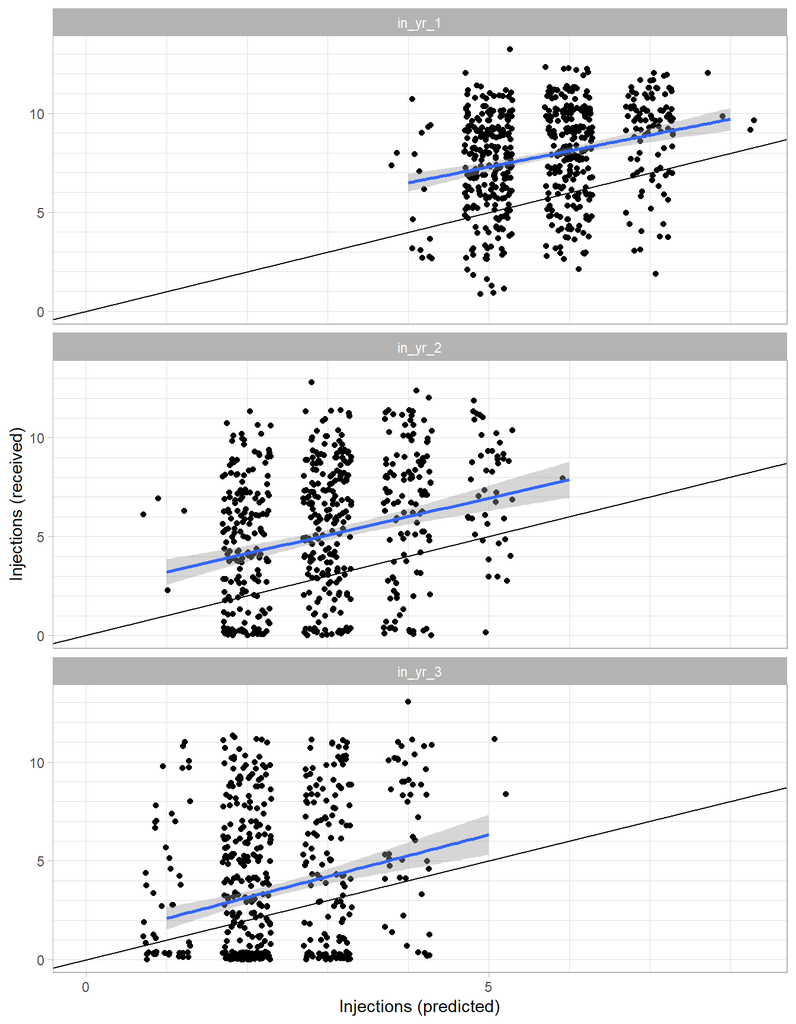

Figure 3.1: Predicted number of injections vs. number of injections received by treatment year. Solid lines indicates calibration slopes (blue = fitted, black = perfect).

# 4 Visual acuity by treatment year

Table 4.1: Prediction characteristics of fitted models by year.

| outcome | method | term | estimate | p |
| --- | --- | --- | --- | --- |
| va_yr_1 | Pearson’s product-moment correlation | NA | 0.53 | < 0.001 |
| va_yr_1 | Linear regression (calibration) | (Intercept) | -0.19 | 0.0017645 |
| va_yr_1 | Linear regression (calibration) | pred_Y | 1.68 | < 0.001 |
| va_yr_1 | Deviation | mean | 0.15 | NA |
| va_yr_1 | Absolute deviation | mean | 0.38 | NA |
| va_yr_2 | Pearson’s product-moment correlation | NA | 0.48 | < 0.001 |
| va_yr_2 | Linear regression (calibration) | (Intercept) | -0.21 | 0.007465 |
| va_yr_2 | Linear regression (calibration) | pred_Y | 1.60 | < 0.001 |
| va_yr_2 | Deviation | mean | 0.11 | NA |
| va_yr_2 | Absolute deviation | mean | 0.40 | NA |
| va_yr_3 | Pearson’s product-moment correlation | NA | 0.45 | < 0.001 |
| va_yr_3 | Linear regression (calibration) | (Intercept) | -0.29 | 0.010222 |
| va_yr_3 | Linear regression (calibration) | pred_Y | 1.54 | < 0.001 |
| va_yr_3 | Deviation | mean | 0.04 | NA |
| va_yr_3 | Absolute deviation | mean | 0.41 | NA |

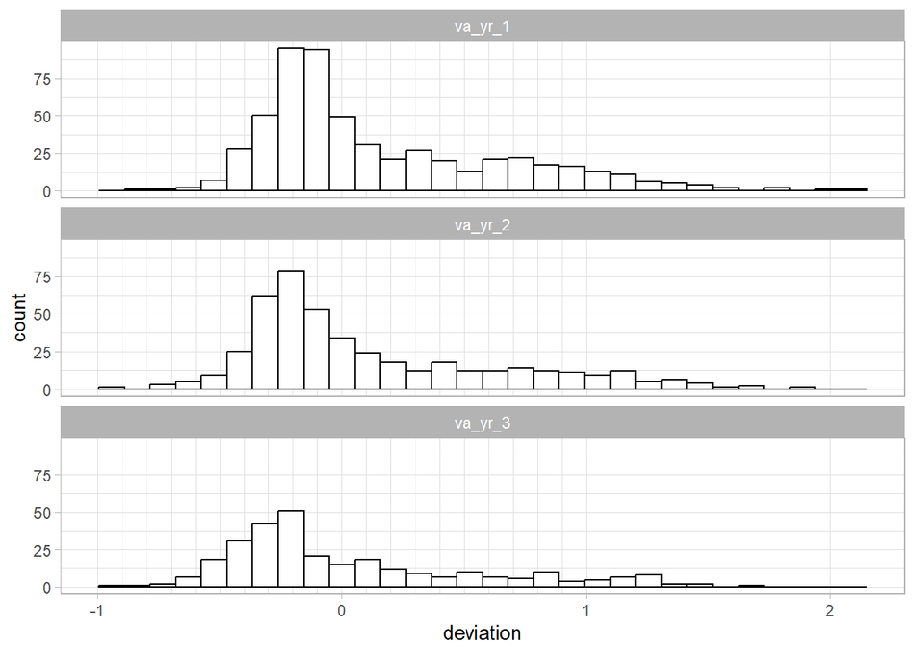

Figure 4.1: Deviations between predicted and observed visual acuity measures by treatment year.

Table 4.2: Absolute deviation between predicted and observed visual acuity by treatment year model.

| absolute_deviation | n_va_yr_1 | n_va_yr_2 | n_va_yr_3 | cumulative_va_yr_1 | cumulative_va_yr_2 | cumulative_va_yr_3 |
| --- | --- | --- | --- | --- | --- | --- |
| (0,0.1] | 18.4% (103) | 15.5% (69) | 10.8% (32) | 18.4% | 15.5% | 10.8% |
| (0.1,0.2] | 22.7% (127) | 17.6% (78) | 15.5% (46) | 41.1% | 33.1% | 26.3% |
| (0.2,0.3] | 16.8% (94) | 21.2% (94) | 18.9% (56) | 57.9% | 54.3% | 45.1% |
| (0.3,0.4] | 11.2% (63) | 14.0% (62) | 16.8% (50) | 69.1% | 68.2% | 62.0% |
| (0.4,0.5] | 6.1% (34) | 6.5% (29) | 10.4% (31) | 75.2% | 74.8% | 72.4% |
| (0.5,0.6] | 3.8% (21) | 4.7% (21) | 7.4% (22) | 78.9% | 79.5% | 79.8% |
| (0.6,0.7] | 3.9% (22) | 2.5% (11) | 3.7% (11) | 82.9% | 82.0% | 83.5% |
| (0.7,0.8] | 3.9% (22) | 4.1% (18) | 3.7% (11) | 86.8% | 86.0% | 87.2% |
| (0.8,0.9] | 2.5% (14) | 2.3% (10) | 3.0% (9) | 89.3% | 88.3% | 90.2% |
| (0.9,1] | 2.7% (15) | 2.7% (12) | 1.7% (5) | 92.0% | 91.0% | 91.9% |
| (1,1.1] | 2.3% (13) | 2.0% (9) | 1.3% (4) | 94.3% | 93.0% | 93.3% |
| (1.1,1.2] | 2.0% (11) | 2.7% (12) | 2.0% (6) | 96.2% | 95.7% | 95.3% |
| (1.2,1.3] | 1.1% (6) | 1.1% (5) | 2.7% (8) | 97.3% | 96.8% | 98.0% |
| (1.3,1.4] | 0.7% (4) | 0.9% (4) | 0.7% (2) | 98.0% | 97.7% | 98.7% |
| (1.4,1.5] | 0.7% (4) | 1.1% (5) | 0.7% (2) | 98.8% | 98.9% | 99.3% |
| NA | 1.2% (7) | 1.1% (5) | 0.7% (2) | 100.0% | 100.0% | 100.0% |

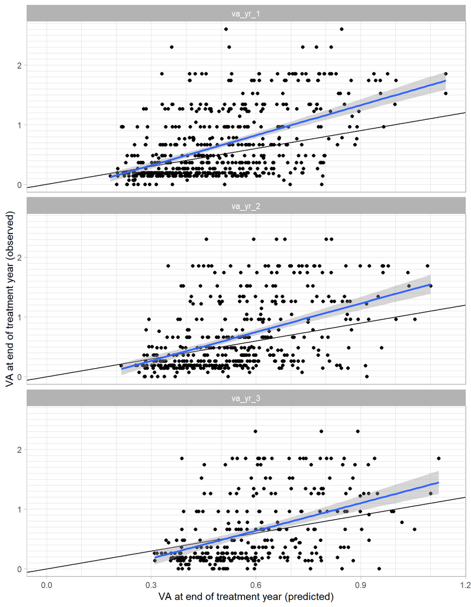

Figure 4.2: Predicted vs. observed visual acuity at the end of each treatment year. Solid lines indicates calibration slopes (blue = fitted, black = perfect).